# icvs_prep_report

The International Crime Victims Survey (ICVS) is a great dataset. Big, easy enough to access, and it’s well documented. The identifiers and labels are available in the dataset, as well as an accompanying codebook updated to the 2005 sweep of the ICVS. There is also a version of the questionnaire that participants see, which has been helpful in interpreting the items in plain language, in addition to clearing up some inconsistencies in the codebook.

# **At a Glance**

```r
nrow(icvs_data)
```

```
## [1] 338056
```

```r
ncol(icvs_data)
```

```
## [1] 141
```

```r
unique(icvs_data$country)
```

```
##  [1] United Kingdom        Indonesia             England & Wales
##  [4] Scotland              Northern Ireland      Netherlands
##  [7] Germany               Switzerland           Belgium
## [10] France                Finland               Spain
## [13] Norway                USA                   Canada
## [16] Australia             Poland                Czech Republic
## [19] Slovak Republic       Georgia               Estonia
## [22] Sweden                Italy                 New Zealand
## [25] Costa Rica            Russia                Slovenia
## [28] Philippines           India                 China
## [31] Uganda                Egypt                 South Africa
## [34] Tanzania              Tunisia               Brazil
## [37] Argentina             Malta                 Lithuania
## [40] Austria               Latvia                Rumania
## [43] Hungary               Yugoslavia            Mongolia
## [46] Kyrgyzstan            Zimbabwe              Bolivia
## [49] Albania               Macedonia             Paraguay
## [52] Ukrain                Bulgaria              Belarus
## [55] Colombia              Botswana              Croatia
## [58] Nigeria               Denmark               Portugal
## [61] Japan                 Zambia                Lesotho
## [64] Swaziland             Namibia               Mozambique
## [67] Cambodia              Republic of Korea     Panama
## [70] Azerbaijan            Greece                Luxembourg
## [73] Ireland               Mexico                Iceland
## [76] Turkey                Hong Kong (SAR China) Peru
## 79 Levels: Albania Argentina Australia Austria Azerbaijan Belarus ... Zimbabwe
```

```r
length(summary(icvs_data$country))
```

```
## [1] 79
```

We see above, that there are 79 countries in total across the entire ICVS.

The ICVS provides more specific regional data compared to the LIS or World Bank, distinguishing data collection across England and Wales, Ireland, Northern Ireland, and Scotland (in addition to the United Kingdom).

```r
summary(icvs_data$country)[c("United Kingdom","England & Wales", "Northern Ireland", "Scotland", "Ireland")]
```

```
##   United Kingdom  England & Wales Northern Ireland         Scotland
##            18937            10018             6555             8266
##          Ireland
##             2003
```

It would be preferable to retain data granularity across the United Kingdom. Firstly, it would keep the number of clusters closer 30 countries, and secondly, the regions likely have important economic and cultural differences. For instance, Northern Ireland has a smaller gini compared to the broader UK (.33 vs. .39 in 2013; https://www.nicva.org/resource/economic-inequality-in-northern-ireland).

Unfortunately, smaller regions seem less likely to systematically collect data. For instance, some critical variables such as income inequality are not available either in the LIS, World Bank, nor government-level data in countries such as Northern Ireland or Scotland. Since this study seeks to integrate individual and nation-level observations, members of the United Kingdom were combined under the single country of the UK.

```r
summary(icvs_data$country)[c("United Kingdom","England & Wales", "Northern Ireland", "Scotland", "Ireland")]
```

```
##   United Kingdom  England & Wales Northern Ireland         Scotland
##            43776                0                0                0
##          Ireland
##             2003
```

```r
sum(summary(icvs_data$country)>0)
```

```
## [1] 75
```

Notably, Ireland is not part of the UK, so has better data coverage and is left separately for this study

# **Data wrangling**

There are many different years and versions of the survey; not every case, sweep, or questionnaire will yield the data we’re looking for.

If we’re doing international comparisons, the most important first consideration is the distribution of responses by sweep year. We need to have cases be (roughly) comparable based on the year. For example, it would be unfair to compare norway in 2005 to lithuania in 1989.

|  | x |
| --- | --- |
| 1st sweep -1989 | 34619 |
| 2nd sweep -1992 -1994 | 44165 |
| 3rd sweep -1995-1998 | 66067 |
| 4th sweep -1999-2003 | 98456 |
| 5th sweep -2004-2006 | 57281 |
| EU ICS 2005 | 37468 |

We can see that there are five major sweeps of data collection, each potentially spanning a couple years. There is also a specific EU sweep, overlapping the 5th sweep.

Next, it’s worthwhile seeing what kinds of questionnaires people get, in case there are any meaningful differences

```r
kable_summary(icvs_data$questionnaire_used)
```

|  | x |
| --- | --- |
| 0 | 9833 |
| cati 89 | 34619 |
| cati 92 | 21284 |
| FtoF 92 | 21048 |
| cati 96 | 26352 |
| FtoF 96 | 30548 |
| FtoF 97 | 7994 |
| country specific | 17540 |
| cati 2000 | 39406 |
| face to face 2000 | 40195 |
| Africa2000 | 8756 |
| EU | 55045 |
| 2000 cati | 0 |
| 2004 face to face | 9024 |
| NA’s | 16412 |

We can see that *there are more than a dozen different surveys distributed as part of this project*: computer-assisted telephone interviewing (CATI), face to face, and something “country specific.” I know with some questionnaires (possibly later, and outside this dataset) are done solely with computers, but those had very poor response rates. Likewise, we can see that the study has been conducted over 15 years, better seen below.

A potentially important note is that 9833 cases have “0” coded as the questionnaire they received, which doesn’t have a code to it. Likewise, 16412 cases are NA. This means about *25,000 participants were given an unknown questionnaire.* More on this later

This is important because the questions they receive, and the time they receive the questions, can change. There are variables that may help us clear this up, but we need to keep this uncertainty in our consideration, because as explored later on, **this study often uses NA values in the place of 0**

The codebook proves to be a useful, but incomplete, resource here. We can see which countries took part in each sweep, and what items were included (it even specifies the order of presentation!).

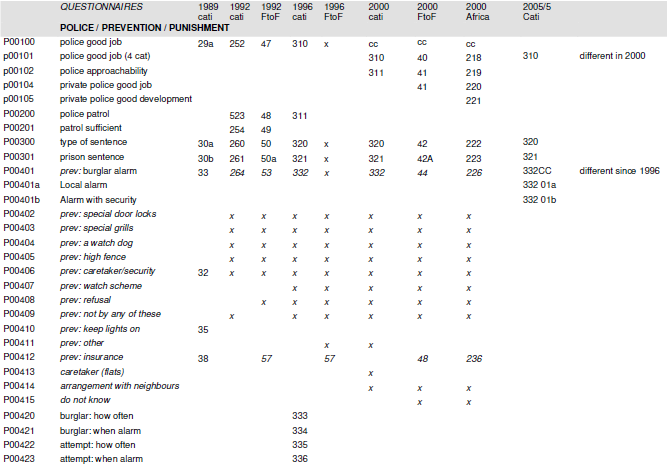

# Choosing year(s) and questionnaire(s) for our analysis

It’s obvious we can’t use all sweeps right off the bat. Although we have the “seal of approval” for comparability, this is for specific questionnaire items - some questions are not displayed to participants in some years/surveys.

This problem best reveals itself when we try to choose nation-level variables to include in the model - if we look at GDP or gini, what year do we extract from?

|  | country | sweep1_1989 | sweep2_1992_94 | sweep3_1995_98 | sweep4_1999_03 | sweep_5_2004_2006 | EU_sweep_2005 | total | eu_and_2005 |
| --- | --- | --- | --- | --- | --- | --- | --- | --- | --- |
| 1 | Albania | NA | NA | 1200 | 1498 | NA | NA | 2698 | NA |
| 2 | Argentina | NA | 1000 | 1000 | 8931 | 5260 | NA | 16191 | 5260 |
| 3 | Australia | 2012 | 2006 | NA | 2005 | 7001 | NA | 13024 | 7001 |
| 4 | Austria | NA | NA | 1507 | NA | NA | 2004 | 3511 | 2004 |
| 5 | Azerbaijan | NA | NA | NA | 930 | NA | NA | 930 | NA |
| 6 | Belarus | NA | NA | 999 | 1520 | NA | NA | 2519 | NA |
| 7 | Belgium | 2060 | 1485 | NA | 2501 | NA | 2014 | 8060 | 2014 |
| 8 | Bolivia | NA | NA | 999 | NA | NA | NA | 999 | NA |
| 9 | Botswana | NA | NA | 644 | 1197 | NA | NA | 1841 | NA |
| 10 | Brazil | NA | 1017 | 1000 | 1400 | NA | NA | 3417 | NA |

[output cut: 65 more lines]

The above shows the number of participants in each country, for each wave, in addition to a total, AS WELL as the total number of participants for each country after combining the overlapping waves 5 and EU ICS (2004-2006 for sweep 5, and 2005 for the EU ICS 5.1)

Although we could compare the sums of eu_and_2005 with its constituents, it’s easier to **sum the number of non-NAs** (i.e., countries with at least 1 respondent) to see whether the 2004-2006 and EU ICS sweeps measure the same countries twice (i.e., there’s redundancy)

| country | sweep1_1989 | sweep2_1992_94 | sweep3_1995_98 | sweep4_1999_03 | sweep_5_2004_2006 | EU_sweep_2005 | total | eu_and_2005 |
| --- | --- | --- | --- | --- | --- | --- | --- | --- |
| 75 | 13 | 30 | 44 | 46 | 18 | 16 | 75 | 34 |

So here we can see that the 4th sweep by has the most countries **WITHOUT NAs**, followed by sweeps 3 then 2

Likewise, we can see that 18+16=34, which is equal to “eu_and_2005,” so there is zero redundancy between the 2004-2006 surveys and the 2005 EU ICS. Given that there’s no overlap, sweep 5 and the EU sweep seem to be perfectly complementary.

For now, let’s assume that we’ll be using the countries combined for sweeps 5 and 5.1.

```r
data_2005 = filter(icvs_data,sweep_num == 5 |sweep_num == "5*")
nrow(data_2005)
```

```
## [1] 94749
```

```r
sum(summary(data_2005$country)>0)
```

```
## [1] 34
```

**94,749 people** and surveyed between 2004 and 2006! Certainly encouraging for our sample size. Like mentioned earlier, there may be variability in the surveys people got in these two 2005 sweeps, so let’s see.

**The argument for using sweep 5 and the EU ICS for our analyses**

Putting my bias out there: I’m inclined to use the combined eu_and_2005 data for our analyses.

A little under half of all countries are were surveyed between 2004 and 2006. This gives a reasonable balance of:

1. the most recent data,
2. small time window encompassing each observation, and
3. a decent number of level 2 clustering variables (which is needed for HLM).

The most notable weakness is that this is data from WEIRD countries. Other, less WEIRD countries (e.g., phillipines, nigeria, india) are better represented throughout sweeps 2 to 4

I consider this topic in need for further discussion (including recognizing even how the newest data is 15 years old)

## Comparability of sweeps and questionnaires

I reached out to John van Kesteren - one of the chief researchers involved in the ICVS:

> "With regards to the different versions, the used questionnaires are much alike. Each country was allowed to ad a small amount of additional questions to the basic questionnaires. If the differences are too big, I used the ‘based on xxx’ qualification. In that case it was up to me to decide whether specific items were comparable to the main questionnaire. If not, they were not included in the main database.

> It sounds a bit arrogant, but if it is in the main database, it has my personal seal of approval and the data are comparable."

# **How do we measure security consumption?**

Some people refused to answer on their use of security measures, so obviously can’t be used for this study.

```r
responders_2005 = filter(data_2005, is.na(prev_refusal))
nrow(responders_2005)
```

```
## [1] 91223
```

```r
sum(summary(responders_2005$country)>0)
```

```
## [1] 34
```

Excluding refused participants leaves us with a total of 34 countries and 91223 respondents.

```r
kable_summary(responders_2005$questionnaire_used)
```

|  | x |
| --- | --- |
| 0 | 0 |
| cati 89 | 0 |
| cati 92 | 0 |
| FtoF 92 | 0 |
| cati 96 | 0 |
| FtoF 96 | 0 |
| FtoF 97 | 0 |
| country specific | 10132 |
| cati 2000 | 0 |
| face to face 2000 | 5156 |
| Africa2000 | 1101 |
| EU | 52138 |
| 2000 cati | 0 |
| 2004 face to face | 8873 |
| NA’s | 13823 |

```r
kable_summary(responders_2005$questionnaire_based_on)
```

|  | x |
| --- | --- |
| 0 | 4862 |
| cati 89 | 0 |
| cati 92 | 0 |
| FtoF 92 | 0 |
| cati 96 | 0 |
| FtoF 96 | 1639 |
| FtoF 97 | 0 |
| country specific | 0 |
| cati 2000 | 2251 |
| face to face 2000 | 0 |
| Africa2000 | 2592 |
| 11 | 15040 |
| 12 | 1943 |
| 2004 face to face | 8138 |
| NA’s | 54758 |

six unique values for the questionnaires received

No immediately discernible pattern for which cases get a based_on designation - Kerstern says If the differences are too big, I used the ‘based on xxx’ qualification."

At this moment, I’d propose we use the following variables as dependent variables:

```
## [1] "prev_burglar_alarm"      "prev_special_door_locks"
## [3] "prev_special_grills"     "prev_high_fence"
## [5] "prev_caretaker_security" "gun_ownership"
```

As mentioned before, each item is either 1 or NA. This is problematic when trying to discern true missing responses from participants saying “no” to that item. NAs could mean that the respondent didn’t see the question, but if a category doesn’t apply to them, they leave it blank.

Tables for each questionnaire can help to determine whether the years have *ANY* “1” responses. This isn’t conclusive, there’s a small probability that a survey item presented to all participants, but no one answers it. At minimum, a FALSE value is a good signal though - participants can’t indicate “yes” to any option if they don’t see it.

| questionnaire_used | total_missing | prev_burglar_alarm | prev_special_door_locks | prev_special_grills | prev_high_fence | prev_caretaker_security | gun_ownership |
| --- | --- | --- | --- | --- | --- | --- | --- |
| country specific | 1 | FALSE | FALSE | FALSE | FALSE | FALSE | TRUE |
| face to face 2000 | 0 | FALSE | FALSE | FALSE | FALSE | FALSE | FALSE |
| Africa2000 | 0 | FALSE | FALSE | FALSE | FALSE | FALSE | FALSE |
| EU | 0 | FALSE | FALSE | FALSE | FALSE | FALSE | FALSE |
| 2004 face to face | 0 | FALSE | FALSE | FALSE | FALSE | FALSE | FALSE |
| NA | 0 | FALSE | FALSE | FALSE | FALSE | FALSE | FALSE |

```r
responders_country_spec <- filter(responders_2005, questionnaire_used == "country specific")
length(responders_country_spec$country)
```

```
## [1] 10132
```

```r
unique(responders_country_spec$country)
```

```
## [1] Peru
## 79 Levels: Albania Argentina Australia Austria Azerbaijan Belarus ... Zimbabwe
```

```r
kable_summary(responders_country_spec$questionnaire_based_on)
```

|  | x |
| --- | --- |
| 0 | 0 |
| cati 89 | 0 |
| cati 92 | 0 |
| FtoF 92 | 0 |
| cati 96 | 0 |
| FtoF 96 | 0 |
| FtoF 97 | 0 |
| country specific | 0 |
| cati 2000 | 0 |
| face to face 2000 | 0 |
| Africa2000 | 0 |
| 11 | 0 |
| 12 | 0 |
| 2004 face to face | 0 |
| NA’s | 10132 |

We see that Peru is the only country that received “country specific” designation, and they got an NA “based on” designation.

However, as we see below, in the overall “based_on” breakdown, “cati 2000” also returned a missing flag for gun ownership

| questionnaire_based_on | total_missing | prev_burglar_alarm | prev_special_door_locks | prev_special_grills | prev_high_fence | prev_caretaker_security | gun_ownership |
| --- | --- | --- | --- | --- | --- | --- | --- |
| 0 | 0 | FALSE | FALSE | FALSE | FALSE | FALSE | FALSE |
| FtoF 96 | 0 | FALSE | FALSE | FALSE | FALSE | FALSE | FALSE |
| cati 2000 | 1 | FALSE | FALSE | FALSE | FALSE | FALSE | TRUE |
| Africa2000 | 0 | FALSE | FALSE | FALSE | FALSE | FALSE | FALSE |
| 11 | 0 | FALSE | FALSE | FALSE | FALSE | FALSE | FALSE |
| 12 | 0 | FALSE | FALSE | FALSE | FALSE | FALSE | FALSE |
| 2004 face to face | 0 | FALSE | FALSE | FALSE | FALSE | FALSE | FALSE |
| NA | 0 | FALSE | FALSE | FALSE | FALSE | FALSE | FALSE |

```
## [1] 2251
```

```
## [1] Hong Kong
## 79 Levels: Albania Argentina Australia Austria Azerbaijan Belarus ... Zimbabwe
```

|  | x |
| --- | --- |
| 0 | 0 |
| cati 89 | 0 |
| cati 92 | 0 |
| FtoF 92 | 0 |
| cati 96 | 0 |
| FtoF 96 | 0 |
| FtoF 97 | 0 |
| country specific | 0 |
| cati 2000 | 0 |
| face to face 2000 | 0 |
| Africa2000 | 0 |
| EU | 0 |
| 2000 cati | 0 |
| 2004 face to face | 0 |
| NA’s | 2251 |

Using the same procedure, we see that Hong Kong (and 2251 respondents) are not seeing (or not reporting on) items on gun ownership

So this suggests that Hong Kong and Peru can’t be used when measuring gun ownership.

**Do we use gun ownership as part of a dv?**

Mentioning the propsect of gun ownership as a security measure, John van Kesteren suggested that firearms a as a preventative measure has been debunked. His 2013 article in *BJC* found that

> “owners of a handgun show increased risk for victimization by violent crime. High ownership levels, however, seem to diminish the victimization level for the less serious violent crimes for the non-owners.”

At baseline I’d like to keep keep gun ownership. Even if guns have a null or inconsistent effect on safety, what matters is that consumers perceive that guns are effective in protection. Just like how real victimization risk is not as important as perceived risk to result in security behaviours. Although people spend resources to get the guns for protection (as do 25% of the gun owners in the paper), the practice doesn’t actually prevent victimization.

What is maybe more pressing is losing Hong Kong and Peru from our dataset - each of them are valuable in getting us closer to non-WEIRD comparisons, and losing us a combined 12383 participants.

So maybe our best bet is getting rid of guns and minimizing the DV set - Up for discussion though

```r
prevention_min2 <- c("prev_burglar_alarm", "prev_special_door_locks", "prev_special_grills", "prev_high_fence", "prev_caretaker_security")
```

| country | total_missing | prev_burglar_alarm | prev_special_door_locks | prev_special_grills | prev_high_fence | prev_caretaker_security |
| --- | --- | --- | --- | --- | --- | --- |
| Argentina | 0 | 0 | 0 | 0 | 0 | 0 |
| Australia | 0 | 0 | 0 | 0 | 0 | 0 |
| Austria | 0 | 0 | 0 | 0 | 0 | 0 |
| Belgium | 0 | 0 | 0 | 0 | 0 | 0 |
| Bulgaria | 0 | 0 | 0 | 0 | 0 | 0 |
| Canada | 0 | 0 | 0 | 0 | 0 | 0 |
| Denmark | 0 | 0 | 0 | 0 | 0 | 0 |
| Estonia | 0 | 0 | 0 | 0 | 0 | 0 |
| Finland | 0 | 0 | 0 | 0 | 0 | 0 |
| France | 0 | 0 | 0 | 0 | 0 | 0 |

[output cut: 25 more lines]

One way of doing our analysis is to simply sum all of the security behaviours

Switzerland actually has all NA values for all of these security items, so needs to be gone

```r
responders_2005 = filter(data_2005, country != "Switzerland")

responders_2005[ , prevention_min1] <- sapply(responders_2005[ , prevention_min1],
                                             function(x) as.numeric(as.character(x)))

responders_2005$total_security <- rowSums(responders_2005[ , prevention_min1], na.rm = TRUE) * NA ^ (rowSums(!is.na(responders_2005[ , prevention_min2])) == 0)

responders_2005$total_security[is.na(responders_2005$total_security)] = 0

summary(responders_2005$total_security)
```

```
##    Min. 1st Qu.  Median    Mean 3rd Qu.    Max.
##   0.000   0.000   1.000   1.122   2.000   6.000
```

This summing procedure gives us a max score of 6 on security consumption, with subtantial positive skew

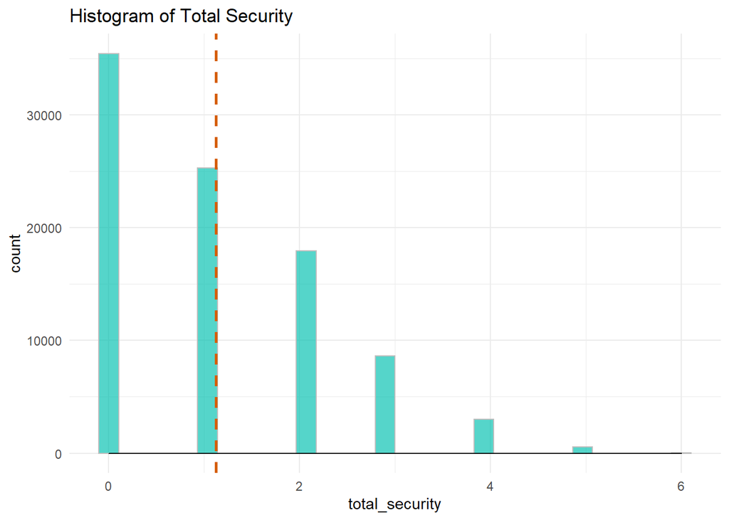

```
## [1] "skewness is"
## [1] 0.8829213
## [1] "kurtosis is"
## [1] 3.130402
```

```
##
##  Jarque-Bera Normality Test
##
## data:  data
## JB = 11868, p-value < 2.2e-16
## alternative hypothesis: greater
```

A question though - is the independence supposed to be observed within observations or between observations?

A more kosher alternative is a square root transformation. Looks like it reduces the skew by a fair amount:

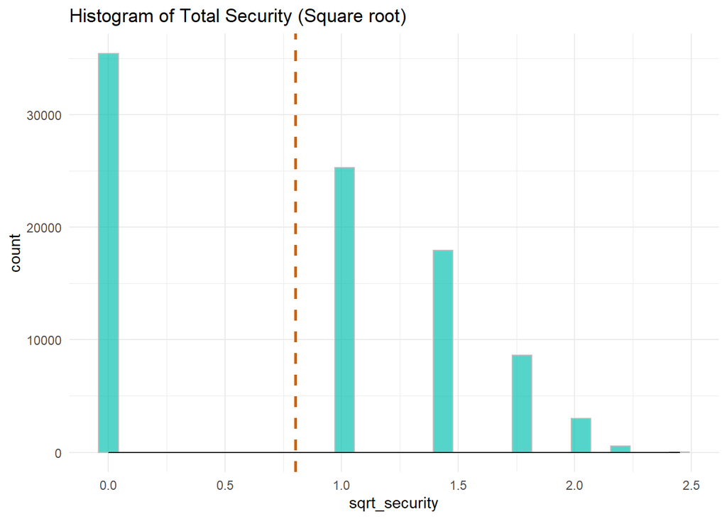

```
## [1] "skewness is"
## [1] -0.003794844
## [1] "kurtosis is"
## [1] 1.557506
```

```
##
##  Jarque-Bera Normality Test
##
## data:  data
## JB = 7877, p-value < 2.2e-16
## alternative hypothesis: greater
```

A last alternative is a condensing transformation. Binning participants to either no security consumption, one unit of consumption, and anything higher than one

All told, let’s remember that the assumptions of normality apply to the distribution of residuals, so can only be interpreted in the model. Good to keep skewness of the DV on our radar though.

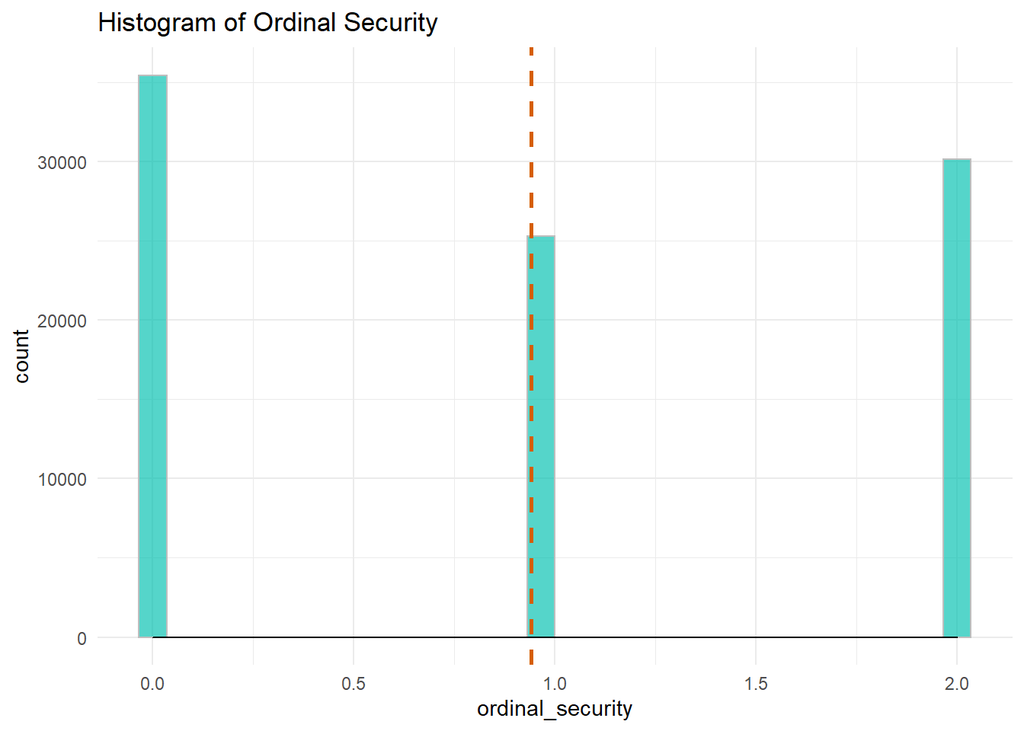

```r
responders_2005$ordinal_security <- NA

responders_2005$ordinal_security <- ifelse(between(responders_2005$total_security,0,1), 1, NA)
responders_2005$ordinal_security[responders_2005$total_security == 0] <- 0
responders_2005$ordinal_security[responders_2005$total_security > 1] <- 2

hist_plot(responders_2005, ordinal_security, "Histogram of Ordinal Security")
```

```r
normality_stats(responders_2005$ordinal_security)
```

```
## [1] "skewness is"
## [1] 0.111436
## [1] "kurtosis is"
## [1] 1.401056
```

```
##
##  Jarque-Bera Normality Test
##
## data:  data
## JB = 9866, p-value < 2.2e-16
## alternative hypothesis: greater
```

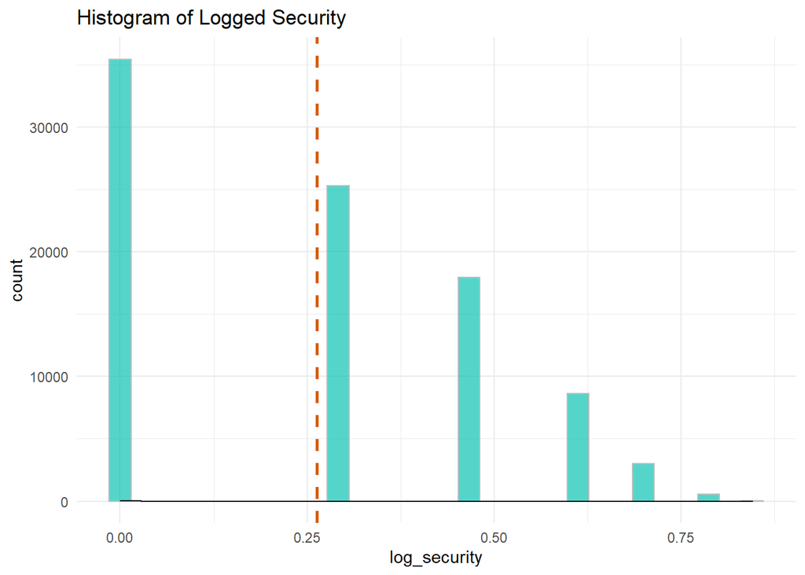

```r
# log+1 method
responders_2005$log_security <- log10(responders_2005$total_security+1)
hist_plot(responders_2005, log_security, "Histogram of Logged Security")
```

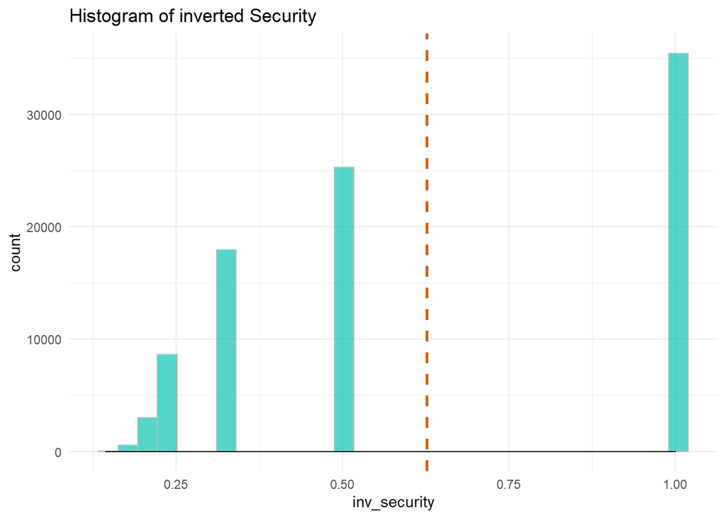

```r
# inverse method
responders_2005$inv_security <- 1/(responders_2005$total_security+1)
hist_plot(responders_2005, inv_security, "Histogram of inverted Security")
```

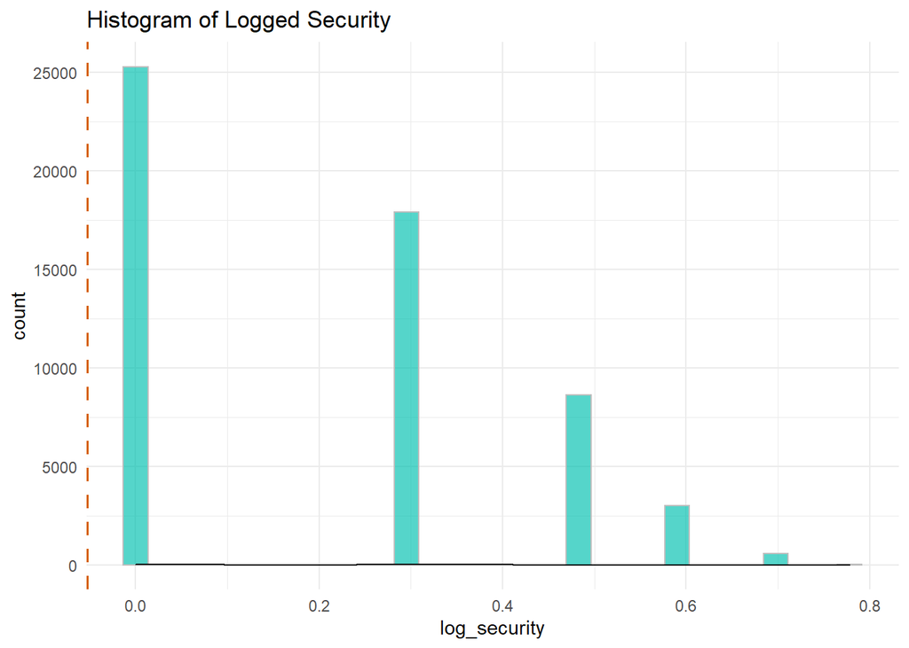

```r
responders_2005$log_security <- log10(responders_2005$total_security)
hist_plot(responders_2005, log_security, "Histogram of Logged Security")
```

```r
normality_stats(responders_2005$log_security)
```

```
## [1] "skewness is"
## [1] NaN
## [1] "kurtosis is"
## [1] NaN
```

```
##
##  Jarque-Bera Normality Test
##
## data:  data
## JB = NaN, p-value = NA
## alternative hypothesis: greater
```

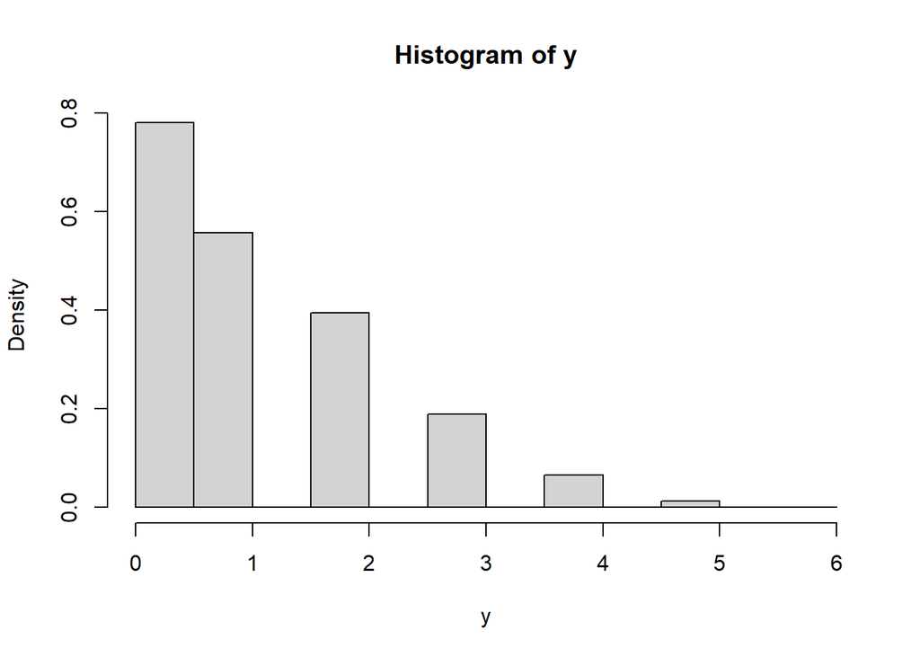

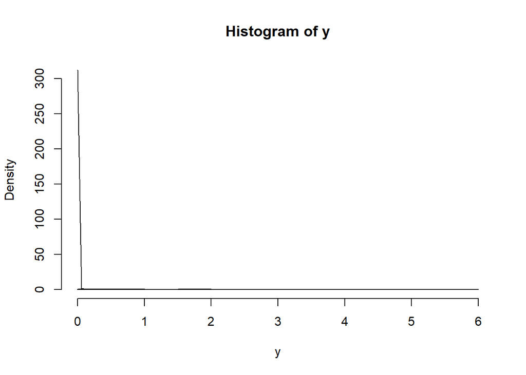

```r
# responders_2005$boxcox_security <- caret::BoxCoxTrans(responders_2005$total_security)

# two-parameter box-cox transformation - allows a shift before transformation:
security_boxcox<- geoR::boxcoxfit(responders_2005$total_security, lambda=0, lambda2 = 1)

security_boxcox_.5<- geoR::boxcoxfit(responders_2005$total_security, lambda=0, lambda2 = .1)

# security_boxcox <- MASS::boxcox(responders_2005$total_security)

plot(security_boxcox)
```

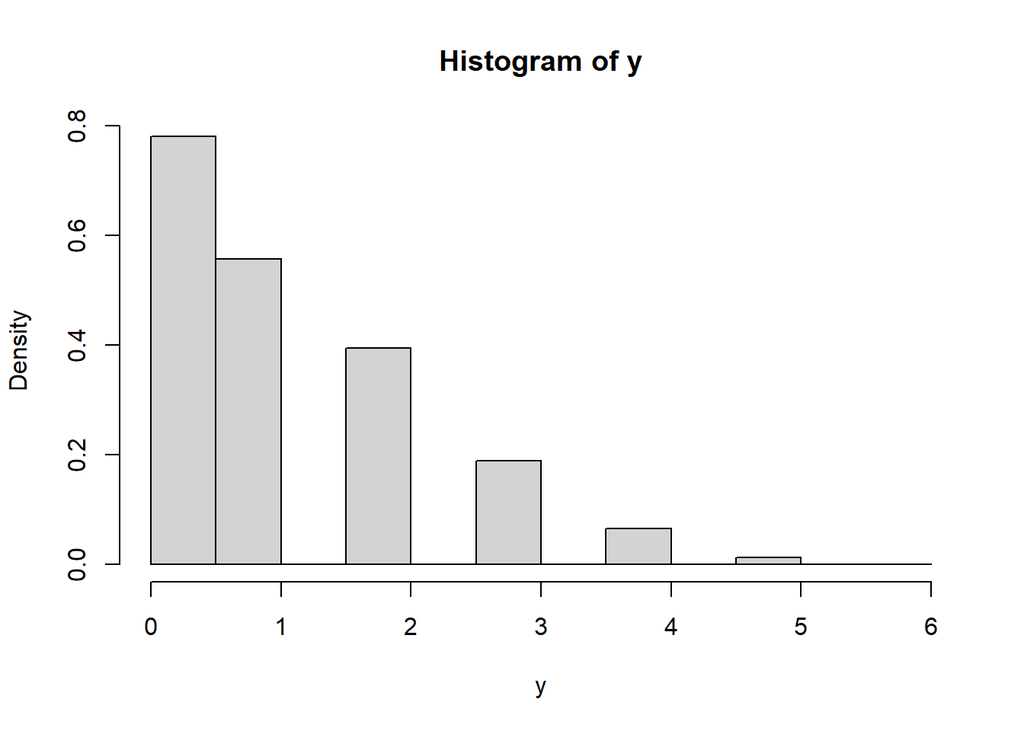

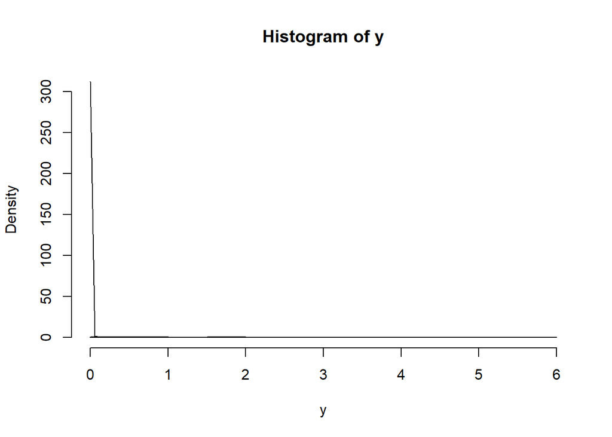

```r
plot(security_boxcox_.5)
```

```r
summary(responders_2005$country)[0!= summary(responders_2005$country)]
```

```
##      Argentina      Australia        Austria        Belgium       Bulgaria
##           5260           7001           2004           2014           1101
##         Canada        Denmark        Estonia        Finland         France
##           2000           1984           1687           2500           2016
##        Germany         Greece        Hungary      Hong Kong        Iceland
##           2025           2020           2103           2283           1910
##        Ireland          Italy          Japan      Lithuania     Luxembourg
##           2003           2023           2086           2000            800
##         Mexico    Netherlands    New Zealand         Norway           Peru
##           1992           2010           2000           3996          10300
##         Poland       Portugal   South Africa          Spain         Sweden
##           5013           2011           1501           2034           2012
##         Turkey United Kingdom  United States
##           1242           7909           2011
```

One of the major benefits of an international study like this is being able to incorporate other nation-level variables. In this case, I am particularly interested in inequality, but it also allows to incorporate basic pieces like country prosperity

```r
nrow(responders_2005) - colSums(is.na(responders_2005[,potential_ivs]))
```

```
##                              gender                                 age
##                               90851                               88232
##                    immigrant_status                      household_size
##                               38979                               82656
##                     persons_over_16                       males_over_16
##                               39401                                3472
##                           town_size                       type_of_house
##                               65085                               42407
##                          home_owner                          occupation
##                                9348                               90849
##                  part_full_time_job                  level_of_education
##                                5013                               16109
##                  years_of_education                              income
##                               78104                               87077
##                             income1                             income2
##                                5633                                7354
##          income_percentile_estimate                    area_description
##                                2010                               14703
##                       lived_in_area                      marital_status
##                               26409                               89070
##    race_ethnicity_1_hispanic_latino              race_ethnicity_2_white
##                                5013                                5013
##      race_ethnicity_2_black_african      race_ethnicity_2_american_indi
##                                5013                                5013
##              race_ethnicity_2_asian      race_ethnicity_2_native_hawaii
##                                5013                                5013
##      race_ethnicity_2_other_pacific                    cartheft_5_years
##                                5013                               90851
##                  motortheft_5_years                  bicyctheft_5_years
##                               89163                               90850
##                     burglar_5_years                     attempt_5_years
##                               90850                               90851
##                     robbery_5_years                  pers_theft_5_years
##                               90851                               90851
##                      sexoff_5_years                     assault_5_years
##                               79507                               80551
##                 assault_5y_domestic                     fraud_last_year
##                               70221                               83351
##                   corrupt_last_year                   hate_crime_5_year
##                               83348                               39479
```

[output cut: 43 more lines]

```
##                                   0                                   0
##                ask_no_caretak_watch                              ask_no
##                                   0                                   0
##                         ask_unknown                           going_out
##                                   0                               85829
##                  talked_about_crime                   family_gatherings
##                               16109                                1492
##                              visits                      visits_evening
##                                4335                                   0
##                       being_visited            youth_parents_upbringing
##                                   0                                5965
##              youth_school_education          youth_poverty_unemployment
##                                5715                                5996
##                      youth_policing                    youth_sentencing
##                                5578                                5485
```

```r
var_40k <- (nrow(responders_2005) - colSums(is.na(responders_2005[,potential_ivs])))[(nrow(responders_2005) - colSums(is.na(responders_2005[,potential_ivs]))) > 40000]

responders_2005[,names(var_40k)] %>%
 summary()
```

```
##      gender           age        household_size            town_size
##  male   :38500   70+    : 9479   2      :21181   -10,000        :16025
##  female :52351   40-44  : 8449   4      :16324   1,000,000+     :14601
##  unknown:    0   35-39  : 8214   3      :14930   10,000-50,000  :11354
##                  30-34  : 7972   1      :13780   unknown        : 7402
##                  45-49  : 7904   5(+)   : 8776   100,000-500,000: 6907
##                  (Other):46214   (Other): 7665   (Other)        : 8796
##                  NA's   : 2619   NA's   : 8195   NA's           :25766
##            type_of_house               occupation    years_of_education
##  (semi)detached   :25107   working          :45397   12     :11086
##  flat appartment  : 9258   retired, disabled:19180   11     : 9109
##  terrace/row house: 6152   keeping home     :11313   16     : 6332
##  shanties         : 1249   still at school  : 7853   14     : 5904
##  unknown          :  379   looking for work : 4961   13     : 5831
##  (Other)          :  262   (Other)          : 2145   (Other):39842
##  NA's             :48444   NA's             :    2   NA's   :12747
##        income              marital_status     cartheft_5_years
##  upper 25%:21678   married        :43742   no owner   :29894
##  25-50%   :18308   single         :24244   yes        : 4196
##  50-75%   :17824   living together: 7487   no         :56705
##  lower 25%:15777   widowed        : 6878   do not know:   56
##  unknown  :10777   divorced       : 6208
##  (Other)  : 2713   (Other)        :  511
##  NA's     : 3774   NA's           : 1781
##    motortheft_5_years   bicyctheft_5_years    burglar_5_years
##  no owner   :78381    no owner   :35190    yes        : 9762
##  yes        :  914    0          :    0    no         :80919
##  no         : 9855    yes        : 9740    do not know:  169
##  do not know:   13    no         :45843    NA's       :    1
##  NA's       : 1688    do not know:   77
##                       NA's       :    1
##
##     attempt_5_years     robbery_5_years    pers_theft_5_years
##  yes        : 9126   yes        : 6556   yes        :15354
##  no         :81395   no         :84209   no         :75282
##  do not know:  330   do not know:   86   do not know:  215
##
##
##
##
```

[output cut: 17 more lines]

```
##  a very good job  : 9856     very safe  :20514     very likely    : 5451
##  a fairly good job:40096     fairly safe:36406     likely         :27361
##  a fairly poor job:13896     bit unsafe :21475     not very likely:47305
##  a very poor job  : 5500     very unsafe: 9076     unknown        : 6301
##  do not know      : 6707     unknown    : 1301     NA's           : 4433
##  NA's             :14796     6          :    0
##                              NA's       : 2079
##             going_out
##  almost every day: 7385
##  once a week     :28232
##  once a month    :18603
##  less            :19005
##  never           :11620
##  unknown         :  984
##  NA's            : 5022
```

```r
# particularly form sexoff and assault, needs to be checked against each candidate country to see if items were administered

victim_2005 <- responders_2005[,names(var_40k)] %>%
 dplyr::select(ends_with("_5_years")) %>%
  mutate_all(funs(dplyr::recode(., "no owner" = 0, "yes" = 1, "no" = 0, "do not know" = NA_real_, `-1`=0, `1`=1, `2` = 0,  .default = NA_real_)))


colnames(victim_2005) <- gsub(x = colnames(victim_2005), pattern = "_5_years", replacement = "_5yrs")

responders_2005[,colnames(victim_2005)] <- victim_2005

na_tally(responders_2005,country,names(victim_2005)) %>%
      bind_rows(summarise(.,
                      across(where(is.numeric), sum),
                      across(where(is.logical), sum),
                      across(where(is.character), ~"Total")))
```

| country | total_missing | cartheft_5yrs | motortheft_5yrs | bicyctheft_5yrs | burglar_5yrs | attempt_5yrs | robbery_5yrs | pers_theft_5yrs | sexoff_5yrs | assault_5yrs |
| --- | --- | --- | --- | --- | --- | --- | --- | --- | --- | --- |
| Argentina | 0 | 0 | 0 | 0 | 0 | 0 | 0 | 0 | 0 | 0 |
| Australia | 1 | 0 | 0 | 0 | 0 | 0 | 0 | 0 | 1 | 0 |
| Austria | 0 | 0 | 0 | 0 | 0 | 0 | 0 | 0 | 0 | 0 |
| Belgium | 0 | 0 | 0 | 0 | 0 | 0 | 0 | 0 | 0 | 0 |
| Bulgaria | 0 | 0 | 0 | 0 | 0 | 0 | 0 | 0 | 0 | 0 |
| Canada | 0 | 0 | 0 | 0 | 0 | 0 | 0 | 0 | 0 | 0 |
| Denmark | 0 | 0 | 0 | 0 | 0 | 0 | 0 | 0 | 0 | 0 |
| Estonia | 1 | 0 | 1 | 0 | 0 | 0 | 0 | 0 | 0 | 0 |
| Finland | 0 | 0 | 0 | 0 | 0 | 0 | 0 | 0 | 0 | 0 |
| France | 0 | 0 | 0 | 0 | 0 | 0 | 0 | 0 | 0 | 0 |

[output cut: 24 more lines]

peru is missing assualts

asutralia missing sexual offences

estonia missing motortheft

probably drop assaults and sexual offences

```r
vic_var_drop <- select(victim_2005,-c("assault_5yrs","sexoff_5yrs"))

# currently keeping
summary(vic_var_drop)
```

```
##  cartheft_5yrs     motortheft_5yrs  bicyctheft_5yrs   burglar_5yrs
##  Min.   :0.00000   Min.   :0.0000   Min.   :0.0000   Min.   :0.0000
##  1st Qu.:0.00000   1st Qu.:0.0000   1st Qu.:0.0000   1st Qu.:0.0000
##  Median :0.00000   Median :0.0000   Median :0.0000   Median :0.0000
##  Mean   :0.04621   Mean   :0.0103   Mean   :0.1073   Mean   :0.1076
##  3rd Qu.:0.00000   3rd Qu.:0.0000   3rd Qu.:0.0000   3rd Qu.:0.0000
##  Max.   :1.00000   Max.   :1.0000   Max.   :1.0000   Max.   :1.0000
##  NA's   :56        NA's   :1701     NA's   :78       NA's   :170
##   attempt_5yrs     robbery_5yrs     pers_theft_5yrs
##  Min.   :0.0000   Min.   :0.00000   Min.   :0.0000
##  1st Qu.:0.0000   1st Qu.:0.00000   1st Qu.:0.0000
##  Median :0.0000   Median :0.00000   Median :0.0000
##  Mean   :0.1008   Mean   :0.07223   Mean   :0.1694
##  3rd Qu.:0.0000   3rd Qu.:0.00000   3rd Qu.:0.0000
##  Max.   :1.0000   Max.   :1.00000   Max.   :1.0000
##  NA's   :330      NA's   :86        NA's   :215
```

```r
# filtering to remove missing variables for summing
responders_2005 <- filter(responders_2005, (!is.na(cartheft_5yrs) & !is.na(bicyctheft_5yrs) & !is.na(burglar_5yrs) & !is.na(attempt_5yrs) & !is.na(robbery_5yrs) & !is.na(pers_theft_5yrs) & !is.na(motortheft_5yrs)))

summary(responders_2005[,names(vic_var_drop)])
```

```
##  cartheft_5yrs     motortheft_5yrs   bicyctheft_5yrs   burglar_5yrs
##  Min.   :0.00000   Min.   :0.00000   Min.   :0.0000   Min.   :0.0000
##  1st Qu.:0.00000   1st Qu.:0.00000   1st Qu.:0.0000   1st Qu.:0.0000
##  Median :0.00000   Median :0.00000   Median :0.0000   Median :0.0000
##  Mean   :0.04635   Mean   :0.01025   Mean   :0.1066   Mean   :0.1068
##  3rd Qu.:0.00000   3rd Qu.:0.00000   3rd Qu.:0.0000   3rd Qu.:0.0000
##  Max.   :1.00000   Max.   :1.00000   Max.   :1.0000   Max.   :1.0000
##   attempt_5yrs     robbery_5yrs     pers_theft_5yrs
##  Min.   :0.0000   Min.   :0.00000   Min.   :0.0000
##  1st Qu.:0.0000   1st Qu.:0.00000   1st Qu.:0.0000
##  Median :0.0000   Median :0.00000   Median :0.0000
##  Mean   :0.1008   Mean   :0.07195   Mean   :0.1688
##  3rd Qu.:0.0000   3rd Qu.:0.00000   3rd Qu.:0.0000
##  Max.   :1.0000   Max.   :1.00000   Max.   :1.0000
```

```r
nrow(responders_2005)
```

```
## [1] 88484
```

```r
# need to get rid of estonia for missingness
responders_2005$num_victim_5yr <- rowSums(responders_2005[,names(vic_var_drop)])

summary(responders_2005$num_victim_5yr)
```

```
##    Min. 1st Qu.  Median    Mean 3rd Qu.    Max.
##  0.0000  0.0000  0.0000  0.6115  1.0000  7.0000
```

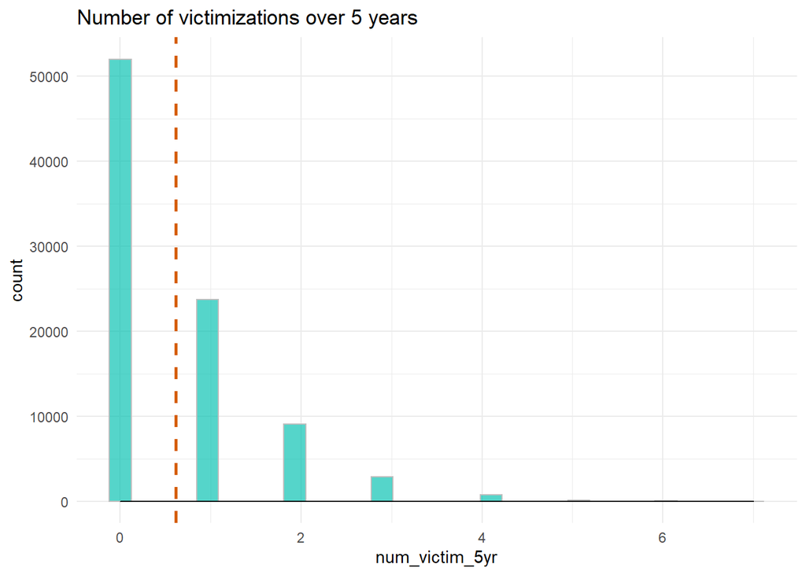

```r
hist_plot(responders_2005,num_victim_5yr,"Number of victimizations over 5 years")
```

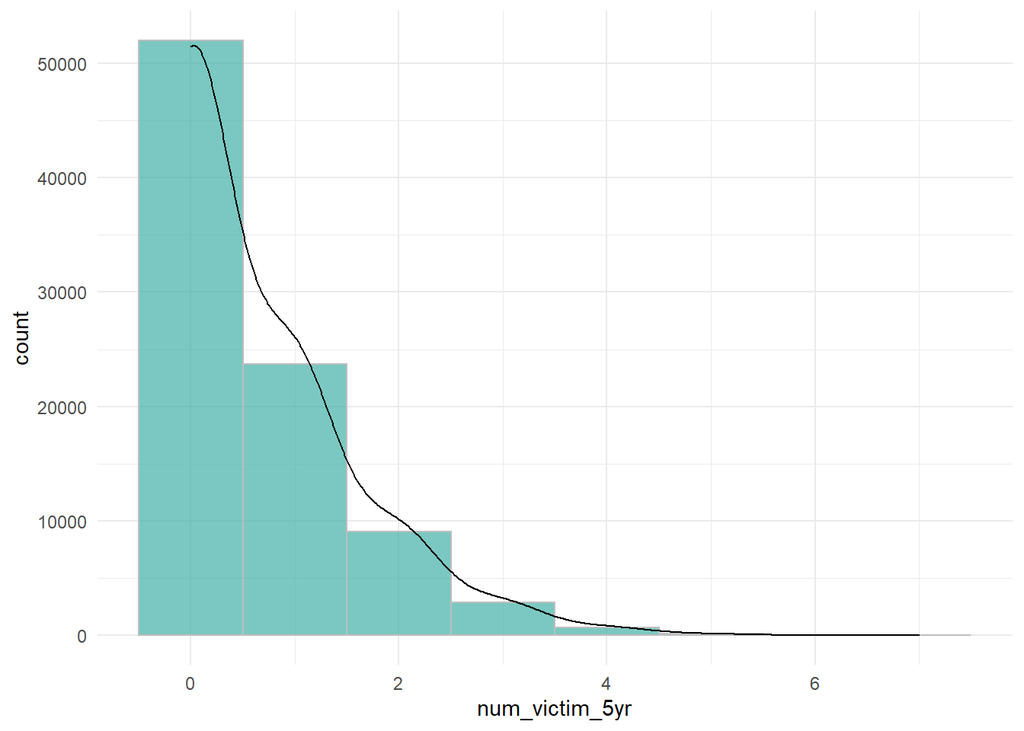

```r
# combined hist and dens(smoothed)
ggplot(responders_2005, aes(x = num_victim_5yr))  +  geom_histogram(binwidth= 1, alpha=.7, fill="#40B0A6", colour='grey') + geom_density(adjust=6, aes(y=..count..)) + theme_minimal()
```

```r
#trying to overlay histogram and density plots
# https://www.datanovia.com/en/blog/ggplot-histogram-with-density-curve-in-r-using-secondary-y-axis/

# ggplot(responders_2005, aes(x = num_victim_5yr)) + geom_density(adjust=6)
#
#
# ggplot(responders_2005, aes(x=num_victim_5yr)) +
#   # Custom the Y scales:
#   scale_y_continuous(
#     # Features of the first axis
#     name = "count",
#     # Add a second axis and specify its features
#     sec.axis = sec_axis( trans=..count.., name="density")
#   ) + geom_histogram(binwidth= 1, alpha=.5, fill="#00C0AFAA", colour='grey')

#
# # 1. Create the histogram plot
# phist <- ggpubr::gghistogram(
#   responders_2005, x = "num_victim_5yr",
#   add = "mean", rug = TRUE, fill="#00C0AFAA", colour='grey'
# )
#
# # 2. Create the density plot with y-axis on the right
# # Remove x axis elements
# pdensity <- ggdensity(
#   responders_2005, x = "num_victim_5yr",
#   alpha = 0,
# ) +
#   scale_y_continuous(expand = expansion(mult = c(0, 0.05)), position = "right")  +
#   cowplot::theme_half_open(11, rel_small = 1) +
#   rremove("x.axis")+
#   rremove("xlab") +
#   rremove("x.text") +
#   rremove("x.ticks") +
#   rremove("legend")
#
# # 3. Align the two plots and then overlay them.
# aligned_plots <- align_plots(phist, pdensity, align="hv", axis="tblr")
# ggdraw(aligned_plots[[1]]) + draw_plot(aligned_plots[[2]])
```

```r
responders_2005$sqrt_victimization <- sqrt(responders_2005$num_victim_5yr) # square root transformation seems to provide something closer, so just use that?
responders_2005$cubrt_victimization <- '^'(responders_2005$num_victim_5yr,1/3)
responders_2005$ordinal_victimization <- NA

responders_2005$ordinal_victimization <- ifelse(between(responders_2005$num_victim_5yr,0,1), 1, NA)
responders_2005$ordinal_victimization[responders_2005$num_victim_5yr == 0] <- 0
responders_2005$ordinal_victimization[responders_2005$num_victim_5yr > 1] <- 2

responders_2005$log_victimization <- log10(responders_2005$num_victim_5yr+1)
```

We’ve sorted out some victimization variables, but there are still some basic demographics and crime-related variables that we need to assess missingness and recode

```r
names(var_40k[-which(names(var_40k) %in% names(victim_2005))])
```

```
## character(0)
```

```r
#make analysis variables
responders_2005 <- responders_2005 %>%
  mutate(male = ifelse(gender=="male", 1, 0),
        age_num = dplyr::recode(as.numeric(age),`1` = 19, `2`=  24, `3` =   29,
                        `4` =   34, `5` =   39,`6` =    44,`7` =    49,`8` =    54,
                        `9` =   59,`10` =   64, `11` =  69, `12` = 75, `13` = NA_real_),
            immigrant = ifelse(immigrant_status=="yes, self", 1, 0),
            household_size_num = dplyr::recode(as.numeric(household_size), `11` = NA_real_),

#housing - apartment as reference?
        house = ifelse(type_of_house =="(semi)detached" | type_of_house =="terrace/row house", 1, ifelse(type_of_house == "flat appartment", 0, ifelse(type_of_house == "institution" | type_of_house == "boat caravan other", 0, ifelse(type_of_house == "shanties", 0, NA)))),
        institution = ifelse(type_of_house =="(semi)detached" | type_of_house =="terrace/row house"| type_of_house == "boat caravan other", 0, ifelse(type_of_house == "flat appartment", 1, ifelse(type_of_house == "institution", 0, ifelse(type_of_house == "shanties", 0, NA)))),
        shanty = ifelse(type_of_house =="(semi)detached" | type_of_house =="terrace/row house"| type_of_house == "boat caravan other", 0, ifelse(type_of_house == "flat appartment", 0, ifelse(type_of_house == "institution", 0, ifelse(type_of_house == "shanties", 1, NA)))),
        other_house = ifelse(type_of_house =="(semi)detached" | type_of_house =="terrace/row house" | type_of_house == "boat caravan other", 1, ifelse(type_of_house == "flat appartment", 0, ifelse(type_of_house == "institution", 0, ifelse(type_of_house == "shanties", 0, NA)))),

        employed = ifelse(occupation == "looking for work" | occupation == "keeping home" | occupation == "retired, disabled" | occupation == "still at school" | occupation == "other", 0, ifelse(occupation == "working" | occupation == "army", 1, NA)),

        income_quartile = ifelse(income == "upper 25%", 4, ifelse(income == "50-75%", 3, ifelse(income == "25-50%", 2, ifelse(income == "lower 25%", 1,NA)))),

        years_edu = as.numeric(as.character(years_of_education)),

        city_size_k = as.numeric(ifelse(town_size == "-10,000", 0, ifelse(town_size == "10,000-50,000", 10,ifelse(town_size == "50,000-100,000",50, ifelse(town_size == "100,000-500,000",100,ifelse(town_size == "500,000-1,000,000",500,ifelse(town_size == "1,000,000+",1000,NA))))))),

        partnered = ifelse(marital_status == "married" | marital_status == "living together", 1, ifelse(marital_status == "single" | marital_status == "divorced" | marital_status == "widowed", 0, NA)),

        police_effective = ifelse(police_good_job_4_cat == "a very poor job",1,ifelse(police_good_job_4_cat == "a fairly poor job",2, ifelse(police_good_job_4_cat == "a fairly good job",3, ifelse(police_good_job_4_cat == "a very good job",4, NA)))),

        feel_safe_dark = ifelse(feel_safe_after_dark == "very unsafe",1,ifelse(feel_safe_after_dark == "bit unsafe",2, ifelse(feel_safe_after_dark == "fairly safe",3, ifelse(feel_safe_after_dark == "very safe",4, NA)))),

        break_in_threat = ifelse(break_in_chances == "not very likely",1,ifelse(break_in_chances == "likely",2, ifelse(break_in_chances == "very likely",3, NA))),

        outing_freq = ifelse(going_out == "never",1,ifelse(going_out == "less",2, ifelse(going_out == "once a month",3,ifelse(going_out == "once a week",4, ifelse(going_out == "almost every day",5, NA))))))
```

```r
new_iv <- names(responders_2005[,ncol(responders_2005):sum(ncol(responders_2005),-16)])
new_iv
```

```
##  [1] "outing_freq"        "break_in_threat"    "feel_safe_dark"
##  [4] "police_effective"   "partnered"          "city_size_k"
##  [7] "years_edu"          "income_quartile"    "employed"
## [10] "other_house"        "shanty"             "institution"
## [13] "house"              "household_size_num" "immigrant"
## [16] "age_num"            "male"
```

```r
new_iv_missing <- responders_2005 %>% group_by(sweep_num) %>%
  count(country)

na_tally(responders_2005,country,all_of(new_iv)) %>%
    bind_rows(summarise(.,
                      across(where(is.numeric), sum),
                      across(where(is.logical), sum),
                      across(where(is.character), ~"Total")))
```

| country | total_missing | outing_freq | break_in_threat | feel_safe_dark | police_effective | partnered | city_size_k | years_edu | income_quartile | employed | other_house | shanty | institution | house | household_size_num | immigrant | age_num | male |
| --- | --- | --- | --- | --- | --- | --- | --- | --- | --- | --- | --- | --- | --- | --- | --- | --- | --- | --- |
| Argentina | 2 | 0 | 0 | 0 | 0 | 0 | 1 | 0 | 0 | 0 | 0 | 0 | 0 | 0 | 0 | 1 | 0 | 0 |
| Australia | 1 | 0 | 0 | 0 | 0 | 0 | 0 | 0 | 0 | 0 | 0 | 0 | 0 | 0 | 0 | 1 | 0 | 0 |
| Austria | 4 | 0 | 0 | 0 | 0 | 0 | 0 | 0 | 0 | 0 | 1 | 1 | 1 | 1 | 0 | 0 | 0 | 0 |
| Belgium | 4 | 0 | 0 | 0 | 0 | 0 | 0 | 0 | 0 | 0 | 1 | 1 | 1 | 1 | 0 | 0 | 0 | 0 |
| Bulgaria | 1 | 0 | 0 | 0 | 0 | 0 | 0 | 0 | 0 | 0 | 0 | 0 | 0 | 0 | 0 | 1 | 0 | 0 |
| Canada | 2 | 0 | 0 | 0 | 0 | 0 | 0 | 0 | 0 | 0 | 0 | 0 | 0 | 0 | 1 | 1 | 0 | 0 |
| Denmark | 4 | 0 | 0 | 0 | 0 | 0 | 0 | 0 | 0 | 0 | 1 | 1 | 1 | 1 | 0 | 0 | 0 | 0 |
| Finland | 4 | 0 | 0 | 0 | 0 | 0 | 0 | 0 | 0 | 0 | 1 | 1 | 1 | 1 | 0 | 0 | 0 | 0 |
| France | 4 | 0 | 0 | 0 | 0 | 0 | 0 | 0 | 0 | 0 | 1 | 1 | 1 | 1 | 0 | 0 | 0 | 0 |
| Germany | 4 | 0 | 0 | 0 | 0 | 0 | 0 | 0 | 0 | 0 | 1 | 1 | 1 | 1 | 0 | 0 | 0 | 0 |

[output cut: 23 more lines]

**A fair bit of missingness among these items**

### what countries should we include?

My initial impression would be to drop japan, estonia, and hong kong for any analysis - not controlling for age and income seems inadvisable

At minimum need to drop hong kong to keep age

### what variables should we include?

**For minimum inclusion:** age, male, employed, partnered (excludes hong kong)

**for moderate inclusion:** police effective, income_quartile (excludes japan, iceland, peru)

# **Nation-level variables**

Our final spread of participants after screening for security items refusers and NAs for IVs (maximizing number of participants over # IVs) is as follows:

```r
iv_2005 <- filter(responders_2005, !is.na(age_num) & !is.na(male) & !is.na(employed) & !is.na(num_victim_5yr))


nrow(iv_2005)
```

```
## [1] 85085
```

```r
summary(iv_2005$country)[summary(iv_2005$country)!= 0]
```

```
##      Argentina      Australia        Austria        Belgium       Bulgaria
##           5169           6518           1987           1986           1057
##         Canada        Denmark        Finland         France        Germany
##           1902           1968           2465           1997           2004
##         Greece        Hungary        Iceland        Ireland          Italy
##           1998           2075           1894           1958           2016
##          Japan      Lithuania     Luxembourg         Mexico    Netherlands
##           2036           1912            790           1967           1993
##    New Zealand         Norway           Peru         Poland       Portugal
##           1961           3956          10284           4985           1994
##   South Africa          Spain         Sweden         Turkey United Kingdom
##           1460           1973           1986           1236           7777
##  United States
##           1781
```

```r
length(summary(iv_2005$country)[summary(iv_2005$country)!= 0])
```

```
## [1] 31
```

```r
iv_2005$male <- factor(iv_2005$male)
iv_2005$employed <- factor(iv_2005$employed)
iv_2005$partnered <- factor(iv_2005$partnered)

iv_2005[,c("age_num", "male", "employed", "partnered", "police_effective", "income_quartile")] %>%
 summary()
```

```
##     age_num      male      employed  partnered    police_effective
##  Min.   :19.00   0:49098   0:41476   0   :35560   Min.   :1.000
##  1st Qu.:34.00   1:35987   1:43609   1   :49079   1st Qu.:2.000
##  Median :44.00                       NA's:  446   Median :3.000
##  Mean   :46.99                                    Mean   :2.775
##  3rd Qu.:59.00                                    3rd Qu.:3.000
##  Max.   :75.00                                    Max.   :4.000
##                                                   NA's   :20886
##  income_quartile
##  Min.   :1.000
##  1st Qu.:2.000
##  Median :3.000
##  Mean   :2.624
##  3rd Qu.:4.000
##  Max.   :4.000
##  NA's   :14377
```

```r
# create dataset with moderate inclusion
iv_2005_mod <- filter(iv_2005, !is.na(police_effective) & !is.na(income_quartile))


# create dataset with liberal inclusion - from moderate dataset (fewest possible participants)
iv_2005_lib <- filter(iv_2005_mod, !is.na(feel_safe_dark) & !is.na(break_in_threat))

# create dataset with liberal-moderate inclusion -from standard dataset (similar to moderate dataset)
iv_2005_lib1 <- filter(iv_2005, !is.na(feel_safe_dark) & !is.na(break_in_threat))
```

```r
iv_2005[,c("age_cent")] <- center_colmeans(iv_2005[,c("age_num")])

nrow(iv_2005)
```

```
## [1] 85085
```

```r
sum(summary(iv_2005$country)>0)
```

```
## [1] 31
```

```r
iv_2005[,c("num_victim_5yr", "age_num", "age_cent")] %>%
 summary()
```

```
##  num_victim_5yr     age_num         age_cent
##  Min.   :0.000   Min.   :19.00   Min.   :-27.989
##  1st Qu.:0.000   1st Qu.:34.00   1st Qu.:-12.989
##  Median :0.000   Median :44.00   Median : -2.989
##  Mean   :0.623   Mean   :46.99   Mean   :  0.000
##  3rd Qu.:1.000   3rd Qu.:59.00   3rd Qu.: 12.011
##  Max.   :7.000   Max.   :75.00   Max.   : 28.011
```

```r
iv_2005_mod[,c("age_cent", "police_eff_cent", "income_cent")] <- center_colmeans(iv_2005_mod[,c("age_num", "police_effective", "income_quartile")])

nrow(iv_2005_mod)
```

```
## [1] 53596
```

```r
sum(summary(iv_2005_mod$country)>0)
```

```
## [1] 28
```

```r
iv_2005_mod[,c("num_victim_5yr", "age_num","police_effective", "income_quartile", "age_cent", "police_eff_cent", "income_cent")] %>%
 summary()
```

```
##  num_victim_5yr      age_num      police_effective income_quartile
##  Min.   :0.0000   Min.   :19.00   Min.   :1.000    Min.   :1.000
##  1st Qu.:0.0000   1st Qu.:34.00   1st Qu.:2.000    1st Qu.:2.000
##  Median :0.0000   Median :49.00   Median :3.000    Median :3.000
##  Mean   :0.5763   Mean   :48.32   Mean   :2.781    Mean   :2.648
##  3rd Qu.:1.0000   3rd Qu.:59.00   3rd Qu.:3.000    3rd Qu.:4.000
##  Max.   :7.0000   Max.   :75.00   Max.   :4.000    Max.   :4.000
##     age_cent        police_eff_cent    income_cent
##  Min.   :-29.3174   Min.   :-1.7809   Min.   :-1.6483
##  1st Qu.:-14.3174   1st Qu.:-0.7809   1st Qu.:-0.6483
##  Median :  0.6826   Median : 0.2191   Median : 0.3517
##  Mean   :  0.0000   Mean   : 0.0000   Mean   : 0.0000
##  3rd Qu.: 10.6826   3rd Qu.: 0.2191   3rd Qu.: 1.3517
##  Max.   : 26.6826   Max.   : 1.2191   Max.   : 1.3517
```

```r
iv_2005_lib[,c("age_cent", "police_eff_cent", "income_cent", "safe_dark_cent", "break_in_threat_cent")] <- center_colmeans(iv_2005_lib[,c("age_num", "police_effective", "income_quartile", "feel_safe_dark", "break_in_threat")])

nrow(iv_2005_lib)
```

```
## [1] 48671
```

```r
sum(summary(iv_2005_lib$country)>0)
```

```
## [1] 27
```

```r
iv_2005_lib[,c("num_victim_5yr", "age_num", "police_effective", "income_quartile", "feel_safe_dark", "break_in_threat", "age_cent", "police_eff_cent", "income_cent", "safe_dark_cent", "break_in_threat_cent")] %>%
 summary()
```

```
##  num_victim_5yr      age_num      police_effective income_quartile
##  Min.   :0.0000   Min.   :19.00   Min.   :1.000    Min.   :1.00
##  1st Qu.:0.0000   1st Qu.:34.00   1st Qu.:2.000    1st Qu.:2.00
##  Median :0.0000   Median :49.00   Median :3.000    Median :3.00
##  Mean   :0.5821   Mean   :47.99   Mean   :2.775    Mean   :2.65
##  3rd Qu.:1.0000   3rd Qu.:59.00   3rd Qu.:3.000    3rd Qu.:4.00
##  Max.   :7.0000   Max.   :75.00   Max.   :4.000    Max.   :4.00
##  feel_safe_dark  break_in_threat    age_cent       police_eff_cent
##  Min.   :1.000   Min.   :1.000   Min.   :-28.992   Min.   :-1.7752
##  1st Qu.:2.000   1st Qu.:1.000   1st Qu.:-13.992   1st Qu.:-0.7752
##  Median :3.000   Median :1.000   Median :  1.008   Median : 0.2248
##  Mean   :2.822   Mean   :1.422   Mean   :  0.000   Mean   : 0.0000
##  3rd Qu.:4.000   3rd Qu.:2.000   3rd Qu.: 11.008   3rd Qu.: 0.2248
##  Max.   :4.000   Max.   :3.000   Max.   : 27.008   Max.   : 1.2248
##   income_cent      safe_dark_cent    break_in_threat_cent
##  Min.   :-1.6503   Min.   :-1.8223   Min.   :-0.4217
##  1st Qu.:-0.6503   1st Qu.:-0.8223   1st Qu.:-0.4217
##  Median : 0.3497   Median : 0.1777   Median :-0.4217
##  Mean   : 0.0000   Mean   : 0.0000   Mean   : 0.0000
##  3rd Qu.: 1.3497   3rd Qu.: 1.1777   3rd Qu.: 0.5783
##  Max.   : 1.3497   Max.   : 1.1777   Max.   : 1.5783
```

```r
iv_2005_lib1[,c("age_cent", "safe_dark_cent", "break_in_threat_cent")] <- center_colmeans(iv_2005_lib1[,c("age_num", "feel_safe_dark", "break_in_threat")])

nrow(iv_2005_lib1)
```

```
## [1] 74295
```

```r
sum(summary(iv_2005_lib1$country)>0)
```

```
## [1] 29
```

```r
iv_2005_lib1[,c("num_victim_5yr", "age_num","feel_safe_dark", "break_in_threat", "age_cent", "safe_dark_cent", "break_in_threat_cent")] %>%
 summary()
```

```
##  num_victim_5yr      age_num      feel_safe_dark  break_in_threat
##  Min.   :0.0000   Min.   :19.00   Min.   :1.000   Min.   :1.000
##  1st Qu.:0.0000   1st Qu.:34.00   1st Qu.:2.000   1st Qu.:1.000
##  Median :0.0000   Median :44.00   Median :3.000   Median :1.000
##  Mean   :0.6395   Mean   :46.64   Mean   :2.762   Mean   :1.486
##  3rd Qu.:1.0000   3rd Qu.:59.00   3rd Qu.:3.000   3rd Qu.:2.000
##  Max.   :7.0000   Max.   :75.00   Max.   :4.000   Max.   :3.000
##     age_cent       safe_dark_cent    break_in_threat_cent
##  Min.   :-27.643   Min.   :-1.7621   Min.   :-0.4857
##  1st Qu.:-12.643   1st Qu.:-0.7621   1st Qu.:-0.4857
##  Median : -2.643   Median : 0.2379   Median :-0.4857
##  Mean   :  0.000   Mean   : 0.0000   Mean   : 0.0000
##  3rd Qu.: 12.357   3rd Qu.: 0.2379   3rd Qu.: 0.5143
##  Max.   : 28.357   Max.   : 1.2379   Max.   : 1.5143
```

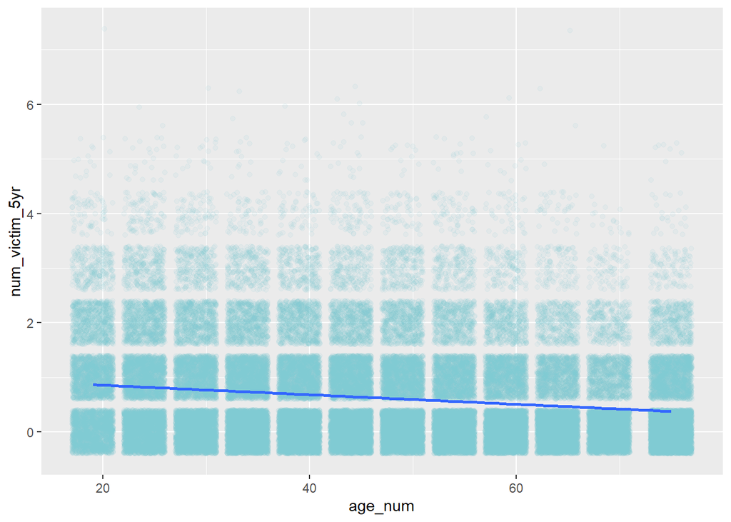

```r
ggplot(iv_2005, aes(x = age_num, y = num_victim_5yr)) +
    geom_jitter(color = "cadetblue3", alpha = .08) + geom_smooth(method = "lm")
```

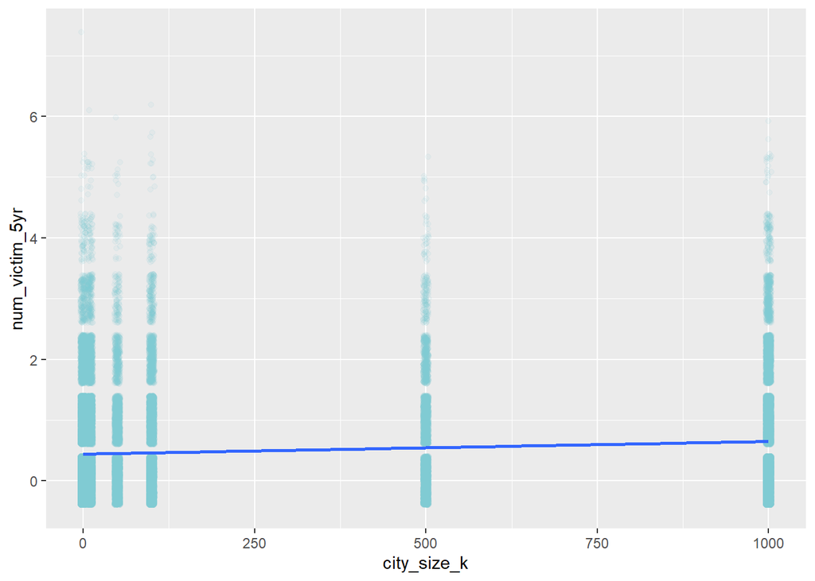

```r
ggplot(iv_2005, aes(x = city_size_k, y = num_victim_5yr)) +
    geom_point(position = "jitter", color = "cadetblue3", alpha = 0.08) + geom_smooth(method = "lm")
```

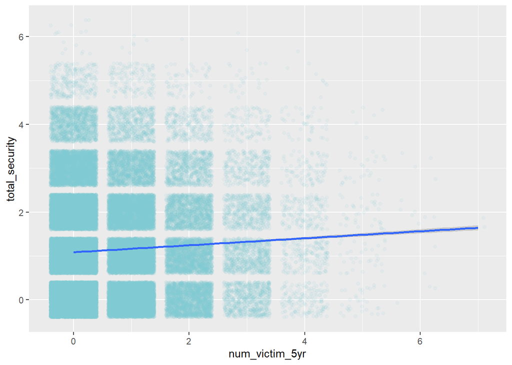

```r
ggplot(iv_2005, aes(x = num_victim_5yr, y = total_security)) +
    geom_point(position = "jitter", color = "cadetblue3", alpha = 0.08) + geom_smooth(method = "lm")
```

```r
#
#
# iv_2005[,155:171] %>%
#  summary()
#
# t_ivar <- c(names(vic_var_drop), "num_victim_5yr", "male", "age_num", "immigrant", "household_size_num", "house", "institution", "shanty", "other_house", "employed", "income_quartile", "years_edu", "city_size_k", "partnered", "police_effective", "feel_safe_dark", "break_in_threat", "outing_freq")
#


#extract weighting variables
#select(contains("_weight"))

#car_ownership
```

## Inequality

For inequality data, I used the Standardized World Income Inequality Database 9.0 (SWIID; Sotler, 2020). It is a great systematic effort at accumulating international comparisons of inequality over time. The Standardized World Income Inequality Database (SWIID) takes a Bayesian approach to standardizing observations collected from the OECD Income Distribution Database, the Socio-Economic Database for Latin America and the Caribbean generated by CEDLAS and the World Bank, Eurostat, the World Bank’s PovcalNet, the UN Economic Commission for Latin America and the Caribbean, national statistical offices around the world, and many other sources. Luxembourg Income Study data serves as the standard.

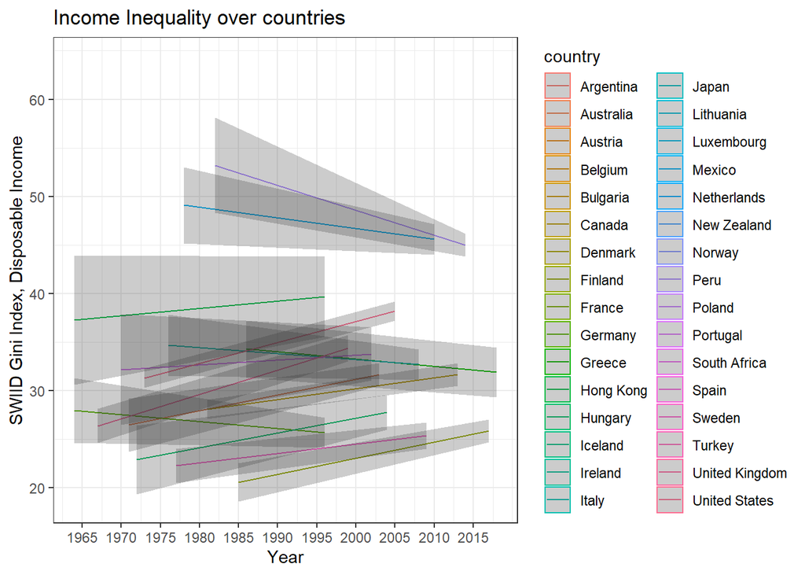

```r
library(purrr)
load("C:/Users/dalla/Google Drive/R Coding/swiid9_0/swiid9_0.rda")


swiid_responders <-  swiid %>%
  map(. %>% filter(.,country %in% names(summary(responders_2005$country)[0!= summary(responders_2005$country)]) )) %>%
  map(. %>% filter(.,year == 2003 | year == 2004 | year == 2005 |year == 2006|year == 2007)) %>%
  map(. %>% select(country,year,gini_disp))


#swiid_spread <- swiid_responders %>%
# map(.%>% spread(., year,gini_disp))


swiid_spread <- swiid_responders %>%
  map(.%>% pivot_wider(names_from = year, names_prefix ="gini_", values_from =gini_disp))


swiid_2004_6 <- swiid_spread %>%
  map(.%>% rowwise() %>%
        mutate(gini_2004_6 = mean(c(gini_2004, gini_2005, gini_2006))))


# swiid_2004_6 <- swiid_2004_6 %>%
#   map(~mutate(., gini_2004_6_cent = gini_2004_6 - mean(gini_2004_6)))
#   # a = mean(gini_2004_6)d
#


for (i in 1:length(swiid_2004_6)) {
    swiid_2004_6[[i]][["gini_2004_6_cent"]] <-  swiid_2004_6[[i]][["gini_2004_6"]] - mean(swiid_2004_6[[i]][["gini_2004_6"]])
}


# swiid_2004_6[[1]][["gini_2004_6_cent"]] <-  swiid_2004_6[[1]][["gini_2004_6"]] - mean(swiid_2004_6[[1]][["gini_2004_6"]])

#plot swiid
swiid_summary %>%
  filter(country == names(summary(responders_2005$country)[0!= summary(responders_2005$country)]) ) %>%
  ggplot(aes(x=year, y=gini_disp, colour = country)) +
  geom_line() +
  geom_ribbon(aes(ymin = gini_disp-1.96*gini_disp_se,
                  ymax = gini_disp+1.96*gini_disp_se,
                  linetype=NA), alpha = .25) +
  scale_x_continuous(breaks=seq(1960, 2015, 5)) +
  theme_bw() +
  labs(x = "Year",
       y = "SWIID Gini Index, Disposable Income",
       title = "Income Inequality over countries")
```

You can see that for the basic summary, there isn’t gini data for all countries in our target study period. Accordingly, the dataset is imputed for some values. The inequality estimates and their associated uncertainty are represented by 100 draws from the posterior distribution: for any given observation, the differences across these imputations capture the uncertainty in the estimate

As described in Solt (2020), the SWIID maximizes the comparability of available income inequality data for the broadest possible sample of countries and years. But incomparability remains, and it is sometimes substantial. This remaining incomparability is reflected in the standard errors of the SWIID estimates, making it often crucial to take this uncertainty into account when making comparisons across countries or over time (Solt 2009, 238; Solt 2016, 14; Solt 2020, 1196).

## Living standards

For a nation-level index of living standards, We’ll use the Penn World Tables 10.0 (Feenstra, Inklaar and Timmer 2015). The PWT is devised to provide real GDP comparisons across countries and over time on the expenditure side. The PWT uses prices collected by the International Comparisons Program to construct purchasing-power-parity exchange rates. The PWT converts GDP at national prices to a common currency – U.S. dollars – making them comparable across countries

[figure not shown]

[figure not shown]

```r
# iv_2005_lib1[,c("age_num","feel_safe_dark", "break_in_threat", "age_cent", "safe_dark_cent", "break_in_threat_cent")] %>%
#  summary()

iv_2005[,c("age_num", "male", "employed", "partnered", "police_effective", "income_quartile", "feel_safe_dark", "break_in_threat")] %>%
 summary()
```

```
##     age_num      male      employed  partnered    police_effective
##  Min.   :19.00   0:49098   0:41476   0   :35560   Min.   :1.000
##  1st Qu.:34.00   1:35987   1:43609   1   :49079   1st Qu.:2.000
##  Median :44.00                       NA's:  446   Median :3.000
##  Mean   :46.99                                    Mean   :2.775
##  3rd Qu.:59.00                                    3rd Qu.:3.000
##  Max.   :75.00                                    Max.   :4.000
##                                                   NA's   :20886
##  income_quartile feel_safe_dark  break_in_threat
##  Min.   :1.000   Min.   :1.000   Min.   :1.000
##  1st Qu.:2.000   1st Qu.:2.000   1st Qu.:1.000
##  Median :3.000   Median :3.000   Median :1.000
##  Mean   :2.624   Mean   :2.769   Mean   :1.485
##  3rd Qu.:4.000   3rd Qu.:3.000   3rd Qu.:2.000
##  Max.   :4.000   Max.   :4.000   Max.   :3.000
##  NA's   :14377   NA's   :3214    NA's   :9810
```

```r
summary(pwt_2004_6$gdppc_2004_6)
```

```
##    Min. 1st Qu.  Median    Mean 3rd Qu.    Max.
##    7091   19743   38622   34968   44204   83904
```

```r
format(summary(pwt_2004_6$gdppc_2004_6), big.mark = ",", scientific = FALSE)
```

```
##     Min.  1st Qu.   Median     Mean  3rd Qu.     Max.
## " 7,091" "19,743" "38,622" "34,968" "44,204" "83,904"
```

```r
summary(pwt_2004_6$gdppc_2004_6)
```

```
##    Min. 1st Qu.  Median    Mean 3rd Qu.    Max.
##    7091   19743   38622   34968   44204   83904
```

```r
gini_mean <- NA
gini_sd <- NA

for (i in 1:length(swiid_2004_6)) {
  gini_mean[i] <- mean(swiid_2004_6[[i]][["gini_2004_6"]])
  gini_sd[i] <- sd(swiid_2004_6[[i]][["gini_2004_6"]])
}

summary(gini_mean)
```

```
##    Min. 1st Qu.  Median    Mean 3rd Qu.    Max.
##   32.87   33.22   33.32   33.32   33.44   33.75
```

```r
summary(gini_sd)
```

```
##    Min. 1st Qu.  Median    Mean 3rd Qu.    Max.
##   8.221   8.447   8.554   8.587   8.691   9.103
```

```r
rm(icvs_data, pwt, swiid, swiid_responders,swiid_spread, data_2005, victim_2005, vic_var_drop, responders_cati_2000,responders_country_spec, iv_2005_lib, iv_2005_lib1, iv_2005_mod)

icvs_joined <- swiid_2004_6 %>%
  map(. %>% left_join(pwt_2004_6, by = c("country"))) %>%
  map(. %>% left_join(iv_2005, by = c("country")))

# %>%
#   map(. %>% filter(., !is.na(num_victim_5yr)))

# icvs_joined <-  icvs_joined %>%
#   map(. %>% filter(., !is.na(num_victim_5yr)))
# rm(icvs_data, pwt, swiid, data_2005)

# rm(list = ls())

save(icvs_joined, file = "C:/Users/dalla/Google Drive/project_files/icvs_inequality/data/icvs_swiid_pwt_joined.RData")
```

# **Summary**

Overall, I think this is a very encouraging first pass. The ICVS is retrievable and interpretable, and above all else, it does indeed measure security behaviours. We also appear to have a reasonable number of countries and participants after some pretty conservative exclusions.

We certainly don’t have to use the summed/transformed/ordinal aggregate of security consumption (opting for something like multiple logistic regressions instead), but being able to condense our analyses will certainly be more powerful for communicating the results.